# Practical Machine Learning: Programming Assignment

### Set packages

```r
library(caret)
library(randomForest)
```

### Data import

- Import data from working directory.

```r
train_pre <- read.csv(file="pml-training.csv",head=TRUE,sep=",")
```

### Data exploration

- Plotting “classe” variable against all other other and summarize {R: summary} all variables.

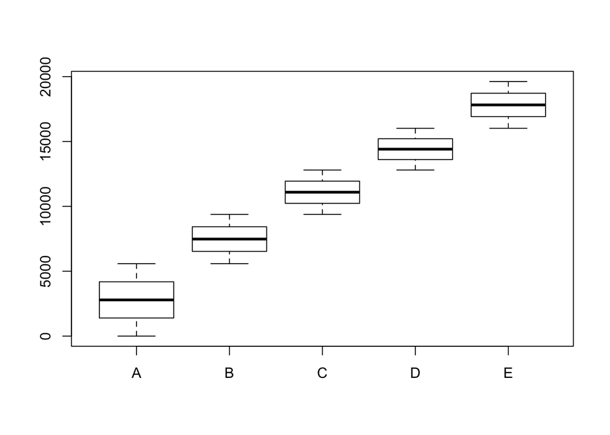

```r
plot(train_pre$classe, train_pre$X)
```

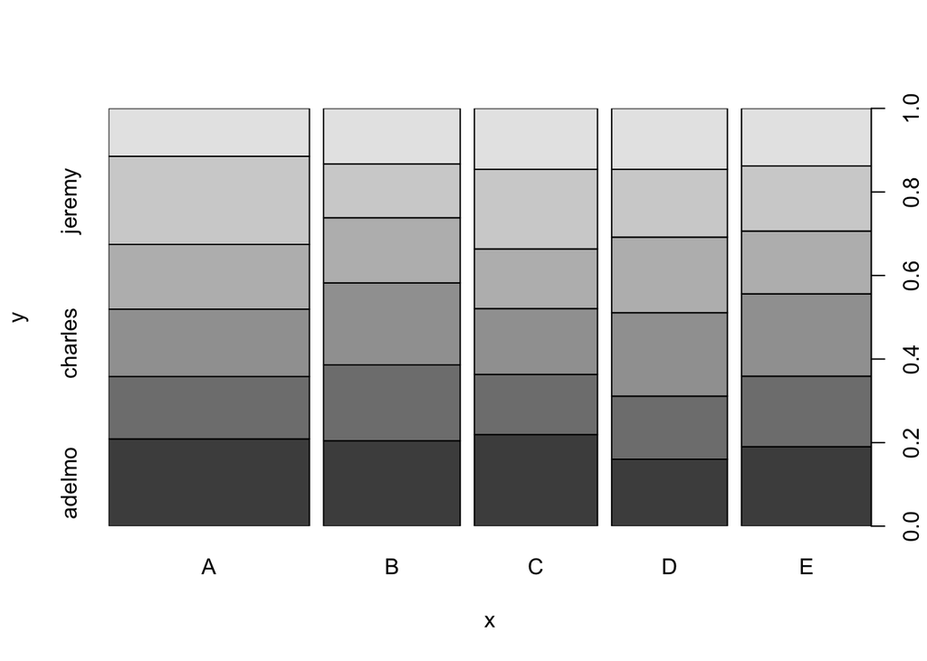

```r
plot(train_pre$classe, train_pre$user_name)
```

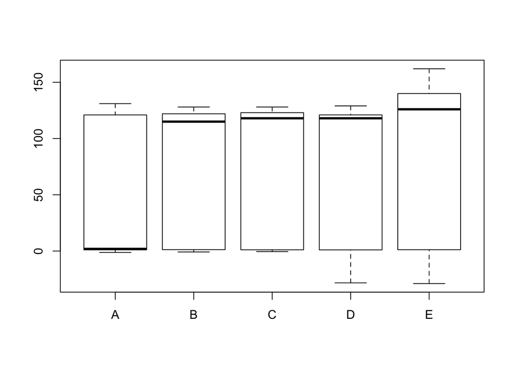

```r
plot(train_pre$classe, train_pre$roll_belt)
```

- There are around 100 variables with more than 50% NAs or empty values.
- Following extreme outliers were identified:

```
train_pre$gyros_dumbbell_x, position 5373, value: -204;
train_pre$gyros_dumbbell_y, position 5373, value: 52;
train_pre$gyros_dumbbell_z, position 5373, value: 317);
train_pre$magnet_dumbbell_y, position 9273, value: -3600.
```

### Data processing

- Add “NA” to all empty fields.
- Remove variables with more than 90% values with NA. The remaining data (0-10%) will most likely not contribute to the models.
- Remove rows with extreme outliers. Those are rare and are most likely errors.
- Remove time variables since they show no pattern and will therefore not contribute to the model:

```
raw_timestamp_part_1;
raw_timestamp_part_2;
cvtd_timestamp;
new_window;
num_window.
```

```r
train_pre[train_pre==""] <- NA
train_pre <- train_pre[, colMeans(is.na(train_pre)) <= .90]
train_pre <- train_pre[, -c(1:7)]
train_pre <- train_pre[-c(5373,9273), ]
```

**Results:**

- There are 52 variables remaining:

  ```
   [1] "roll_belt"            "pitch_belt"           "yaw_belt"
   [4] "total_accel_belt"     "gyros_belt_x"         "gyros_belt_y"
   [7] "gyros_belt_z"         "accel_belt_x"         "accel_belt_y"
  [10] "accel_belt_z"         "magnet_belt_x"        "magnet_belt_y"
  [13] "magnet_belt_z"        "roll_arm"             "pitch_arm"
  [16] "yaw_arm"              "total_accel_arm"      "gyros_arm_x"
  [19] "gyros_arm_y"          "gyros_arm_z"          "accel_arm_x"
  [22] "accel_arm_y"          "accel_arm_z"          "magnet_arm_x"
  [25] "magnet_arm_y"         "magnet_arm_z"         "roll_dumbbell"
  [28] "pitch_dumbbell"       "yaw_dumbbell"         "total_accel_dumbbell"
  [31] "gyros_dumbbell_x"     "gyros_dumbbell_y"     "gyros_dumbbell_z"
  [34] "accel_dumbbell_x"     "accel_dumbbell_y"     "accel_dumbbell_z"
  [37] "magnet_dumbbell_x"    "magnet_dumbbell_y"    "magnet_dumbbell_z"
  [40] "roll_forearm"         "pitch_forearm"        "yaw_forearm"
  [43] "total_accel_forearm"  "gyros_forearm_x"      "gyros_forearm_y"
  [46] "gyros_forearm_z"      "accel_forearm_x"      "accel_forearm_y"
  [49] "accel_forearm_z"      "magnet_forearm_x"     "magnet_forearm_y"
  [52] "magnet_forearm_z"
  ```

### Model creation

- Create data partition of data set: training 75% and testing 25% of the data.
- Create model with “Random Forest (rf)” method with train function {R: train()} function. y = “classe”; x = all remaining 52 variables.
- Reason for choosing rf method was due to the fact that the outcome to be predicted is categorical/nominal, i.e. 5 possible outcomes A, B, C, D and E. A disadvantage is that computing random forest model is relatively time consuming.

```r
train <- train_pre
set.seed(1976)
inTrain <- createDataPartition(y=train$classe, p=.75, list=FALSE)
training <- train[inTrain,]
testing <- train[-inTrain,]
model_rf <- train(classe ~ ., method="rf", data=training)
model_rf
summary(model_rf)
```

*Random Forest model summary:*

- 14717 samples
- 52 predictors
- 5 classes: ‘A’, ‘B’, ‘C’, ‘D’, ‘E’
- No pre-processing
- Resampling: Bootstrapped (25 reps)
- Summary of sample sizes: 14717, 14717, 14717, 14717, 14717, 14717, …
- Resampling results across tuning parameters: Accuracy was used to select the optimal model using the largest value. The final value used for the model was mtry = 2.

| mtry | Accuracy | Kappa | Accuracy SD | Kappa SD |
| --- | --- | --- | --- | --- |
| 2 | 0.99 | 0.987 | 0.00142 | 0.00179 |
| 27 | 0.989 | 0.986 | 0.00134 | 0.0017 |
| 52 | 0.979 | 0.973 | 0.0034 | 0.00431 |

|  | Length | Class | Mode |
| --- | --- | --- | --- |
| call | 4 | none | call |
| type | 1 | none | character |
| predicted | 14717 | factor | numeric |
| err.rate | 3000 | none | numeric |
| confusion | 30 | none | numeric |
| votes | 73585 | matrix | numeric |
| oob.times | 14717 | none | numeric |
| classes | 5 | none | character |
| importance | 52 | none | numeric |
| importanceSD | 0 | none | NULL |
| localImportance | 0 | none | NULL |
| proximity | 0 | none | NULL |
| ntree | 1 | none | numeric |
| mtry | 1 | none | numeric |
| forest | 14 | none | list |
| y | 14717 | factor | numeric |
| test | 0 | none | NULL |
| inbag | 0 | none | NULL |
| xNames | 52 | none | character |
| problemType | 1 | none | character |
| tuneValue | 1 | data.frame | list |
| obsLevels | 5 | none | character |

### Cross-validation:

- The model is cross-validated in the “testing” data set.

```r
set.seed(1976)
prediction <- predict(model_rf, testing)
summary(prediction)
confusionMatrix(testing$classe,predict(model_rf, testing))
```

**Results:**

*Outcome of prediction:*

| A | B | C | D | E |
| --- | --- | --- | --- | --- |
| 1405 | 949 | 859 | 790 | 900 |

*Confusion matrix and Statistics including out-of-sample-errors:*

|  | Reference A | Reference B | Reference C | Reference D | Reference E |
| --- | --- | --- | --- | --- | --- |
| **Prediction A** | 1394 | 0 | 0 | 0 | 0 |
| **Prediction B** | 11 | 934 | 4 | 0 | 0 |
| **Prediction C** | 0 | 15 | 840 | 0 | 0 |
| **Prediction D** | 0 | 0 | 15 | 789 | 0 |
| **Prediction E** | 0 | 0 | 0 | 1 | 900 |

*Overall Statistics:*

- Accuracy: 0.9906
- 95% CI: (0.9875, 0.9931)
- No Information Rate: 0.2866
- P-Value [Acc > NIR]: < 2.2e-16
- Kappa: 0.9881
- Mcnemar’s Test P-Value: NA

*Expected out of sample errors by group:*

|  | Group: A | Group: B | Group: C | Group: D | Group: E |
| --- | --- | --- | --- | --- | --- |
| Sensitivity | 0.9922 | 0.9842 | 0.9779 | 0.9987 | 1.0000 |
| Specificity | 1.0000 | 0.9962 | 0.9963 | 0.9964 | 0.9998 |
| Pos Pred Value | 1.0000 | 0.9842 | 0.9825 | 0.9813 | 0.9989 |
| Neg Pred Value | 0.9969 | 0.9962 | 0.9953 | 0.9998 | 1.0000 |
| Prevalence | 0.2866 | 0.1936 | 0.1752 | 0.1611 | 0.1836 |
| Detection Rate | 0.2843 | 0.1905 | 0.1713 | 0.1609 | 0.1836 |
| Detection Prevalence | 0.2843 | 0.1936 | 0.1744 | 0.1640 | 0.1838 |
| Balanced Accuracy | 0.9961 | 0.9902 | 0.9871 | 0.9975 | 0.9999 |